# KC and KPC semiquantitative

Sara Söderqvist

2025-03-18

This script is exploring whether the markers HMGA2, GATA6 and Galectin-4 are differentially expressed in: - PanINs KC vs tumor in KPC mice - Subanalysis for KC mice: High grade vs low-grade PanIN - Subanalysis for KPC mice: tumor in the overall tissue locations (adipose vs) stroma vs lobules.

One section from each mouse was stained for Galectin-4_Vimentin, and one for HMGA2_GATA6 with immunofluorescence, counterstained with DAPI.

Quantification was performed in a semiquantitative manner by CFM and SSÖ. Scores were assigned per image by opening them in Qupath setting an as strict LUT setting as possible in order to display positive vs negative cells for the respective markers. Consequently, scorings were done considering the positive marker distribution, rather than the marker intensity, and compiled manually in an excel-sheet, separate for KC and KPC.

n = 4 KC mice (named: 45, 46, 49 and 56) n = 4 KPC mice (named: 436-3B, 436-5, 436-7 and 605-4)

A 5-grade score for the semiquantitative analysis in excel was applied as following:

```r
library(dplyr)
```

```r
library(ggplot2)
library(ggthemes)
library(RColorBrewer)
library(reshape2)
library(rstatix)
library(ggpubr)
```

```r
semiq <- factor(c('++++', '+++', '++', '+', '-'))
numeric_semiq <- (c(4, 3, 2, 1, 0))
explanation <- c("all or almost all cells are positive",
            "more than half of the cells are positive",
            "less than half of the cells are positive",
            "few, scarce cells are positive",
            "all cells are negative")

semiq_legend <- data.frame(semiq, numeric_semiq, explanation)
semiq_legend
```

```
##   semiq numeric_semiq                              explanation
## 1  ++++             4     all or almost all cells are positive
## 2   +++             3 more than half of the cells are positive
## 3    ++             2 less than half of the cells are positive
## 4     +             1           few, scarce cells are positive
## 5     -             0                   all cells are negative
```

For images from KC mice, the scoring was applied considering *only* PanINs, separated for high - and -low grade.

For images from KPC mice, the scoring was applied considering *only* the tumor cells. An assignment of the compartment that most tumor cells were present in was also added. For the KC mice, since they were PanINs, the dominant compartment is in general implied to be lobular.

```r
setwd("/Users/sara.soderqvist/Library/CloudStorage/OneDrive-KarolinskaInstitutet/Writing_/Adaptive PDAC paper/Code/source data files to read in/In vivo") # adjust the working directory

KC_og <- read.csv('read in_in vivo_semiq_KC.csv',
                                  sep = ';', header = TRUE)

KPC_og <- read.csv('read in_in vivo_semiq_KPC.csv',
                                  sep = ';', header = TRUE)
# remove residuals from excel export
KC <- KC_og[, -10]
KPC <- KPC_og[-c(11:13),]

KC <- KC %>% mutate_at(c('Gal4_L', 'GATA6_L', 'HMGA2_L', 'Gal4_H', 'GATA6_H', 'HMGA2_H'), as.numeric)
str(KC)
```

‘data.frame’: 23 obs. of 9 variables: $ Mouse : int 45 45 45 45 45 45 45 46 46 46 … $ Image : chr “Lobule A” “Lobule B” “Lobule C” “Lobule D” … $ Mouse_type: chr “KC” “KC” “KC” “KC” … $ Gal4_L : num NA 2 3 3 3 4 3 2 3 3 … $ GATA6_L : num NA 4 NA 4 3 4 3 3 3 4 … $ HMGA2_L : num NA 0.1 NA 0.1 0.1 0.1 0.1 1 0.1 0.1 … $ Gal4_H : num 1 0.1 0.1 0.1 1 0.1 0.1 NA 0.1 0.1 … $ GATA6_H : num 2 NA NA 3 3 2 1 NA 3 2 … $ HMGA2_H : num 0.1 NA NA 1 1 3 0.1 NA 2 1 …

```r
knitr::kable(head(KPC))
```

| Mouse | Image | Mouse_type | Gal4 | GATA6 | HMGA2 | Dominant.compartment.of.image |
| --- | --- | --- | --- | --- | --- | --- |
| 436-3B | Adipose C | KPC | 2 | 2 | 3 | Adipose |
| 436-3B | Adipose B | KPC | 2 | 2 | 2 | Adipose |
| 436-3B | Adipose A | KPC | 3 | 3 | 3 | Adipose |
| 436-5 | Lobule A | KPC | 3 | 4 | 3 | Lobular |
| 436-5 | Stroma A | KPC | 2 | 2 | 4 | Stroma |
| 436-7 | Lobule A | KPC | 2 | 3 | 4 | Lobular |

```r
knitr::kable(head(KC))
```

| Mouse | Image | Mouse_type | Gal4_L | GATA6_L | HMGA2_L | Gal4_H | GATA6_H | HMGA2_H |
| --- | --- | --- | --- | --- | --- | --- | --- | --- |
| 45 | Lobule A | KC | NA | NA | NA | 1.0 | 2 | 0.1 |
| 45 | Lobule B | KC | 2 | 4 | 0.1 | 0.1 | NA | NA |
| 45 | Lobule C | KC | 3 | NA | NA | 0.1 | NA | NA |
| 45 | Lobule D | KC | 3 | 4 | 0.1 | 0.1 | 3 | 1.0 |
| 45 | Lobule E | KC | 3 | 3 | 0.1 | 1.0 | 3 | 1.0 |
| 45 | Lobule F | KC | 4 | 4 | 0.1 | 0.1 | 2 | 3.0 |

```r
KPC_s <- split(KPC, f = KPC$Mouse)
KPC_meancalc <- lapply(KPC_s, function (a) {
  a$GATA6_mean <- round(mean(a$GATA6))
  a$HMGA2_mean <- round(mean(a$HMGA2))
  a$Gal4_mean <- round(mean(a$Gal4))
  a
})
#KPC_meancalc

KPC_mean_b <- bind_rows(KPC_meancalc)
KPC_mean_a <- KPC_mean_b[, -c(2, 4:7)]
KPC_mean <- unique(KPC_mean_a)
KPC_mean # this contains the mean for each KPC mouse.
```

```
##    Mouse Mouse_type GATA6_mean HMGA2_mean Gal4_mean
## 1 436-3B        KPC          2          3         2
## 4  436-5        KPC          3          4         2
## 6  436-7        KPC          3          4         2
## 7  605-4        KPC          4          2         3
```

```r
KC_s <- split(KC, f = KC$Mouse)

KC_meancalc <- lapply(KC_s, function (a) {
  a$GATA6_mean <- round((mean(a$GATA6_L, na.rm = TRUE) + mean(a$GATA6_H, na.rm = TRUE))/2) # mean of the means for both High grade and low grade PanINs
  a$HMGA2_mean <- round((mean(a$HMGA2_L, na.rm = TRUE) + mean(a$HMGA2_H, na.rm = TRUE))/2)
  a$Gal4_mean <- round((mean(a$Gal4_L, na.rm = TRUE) + mean(a$Gal4_H, na.rm = TRUE))/2)
  a
})
#KC_meancalc

KC_mean_b <- bind_rows(KC_meancalc)

KC_mean_a <- KC_mean_b[, -c(2, 4:9)]
KC_mean <- unique(KC_mean_a)
KC_mean # this contains the mean for each KC mouse.
```

```
##    Mouse Mouse_type GATA6_mean HMGA2_mean Gal4_mean
## 1     45         KC          3          1         2
## 8     46         KC          3          1         2
## 16    49         KC          4          1         2
## 20    56         KC          4          1         2
```

Bars showing relative frequencies

```r
KC_mean$Mouse <- as.factor(KC_mean$Mouse)
KPC_mean$Mouse <- as.factor(KPC_mean$Mouse)
KC_KPCmeans <- bind_rows(KC_mean, KPC_mean)
KC_KPCmeans <- KC_KPCmeans %>% mutate_at(c('GATA6_mean', 'HMGA2_mean', 'Gal4_mean'), as.factor)

mKC_KPCmeans <- melt(KC_KPCmeans, id.vars = c("Mouse", "Mouse_type"), value.name = "Mean_value", variable.name = "Marker")
```

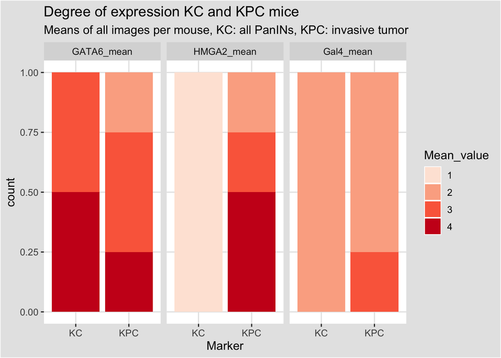

```r
mKC_KPCmeans$semiq <- factor(nrow(mKC_KPCmeans))
mKC_KPCmeans <- mKC_KPCmeans %>% mutate(semiq = ifelse(grepl('1', .$Mean_value), '+', .$semiq))
mKC_KPCmeans <- mKC_KPCmeans %>% mutate(semiq = ifelse(grepl('2', .$Mean_value), '++', .$semiq))
mKC_KPCmeans <- mKC_KPCmeans %>% mutate(semiq = ifelse(grepl('3', .$Mean_value), '+++', .$semiq))
mKC_KPCmeans <- mKC_KPCmeans %>% mutate(semiq = ifelse(grepl('4', .$Mean_value), '++++', .$semiq))

bars_meanspermouse <- mKC_KPCmeans %>% ggplot(aes(x = Mouse_type, fill = Mean_value)) +
  geom_bar(position = "fill") +
  labs(title = "Degree of expression KC and KPC mice", subtitle = "Means of all images per mouse, KC: all PanINs, KPC: invasive tumor", x = "Marker") +
  facet_grid(. ~ Marker) +
  theme_igray() +
  scale_fill_brewer(palette = "Reds")
bars_meanspermouse
```

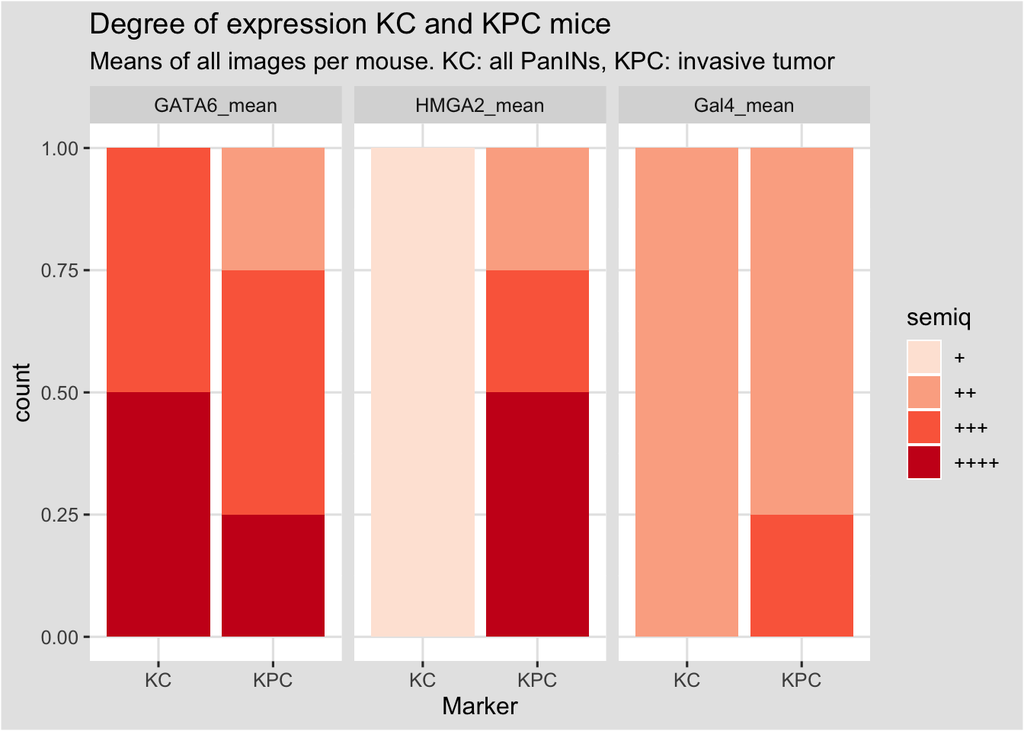

```r
bars_meanspermouse_semiq <- mKC_KPCmeans %>% ggplot(aes(x = Mouse_type, fill = semiq)) +
  geom_bar(position = "fill") +
  labs(title = "Degree of expression KC and KPC mice", subtitle = "Means of all images per mouse. KC: all PanINs, KPC: invasive tumor", x = "Marker") +
  facet_grid(. ~ Marker) +
  theme_igray() +
  scale_fill_brewer(palette = "Reds")
bars_meanspermouse_semiq
```

Focusing on Gal4 and HMGA2

```r
mKC_KPCmeans_GH <- mKC_KPCmeans[mKC_KPCmeans$Marker != "GATA6_mean", ]
mKC_KPCmeans_GH$Marker <- factor(mKC_KPCmeans_GH$Marker, levels = c("HMGA2_mean", "Gal4_mean"))
levels(mKC_KPCmeans_GH$Marker)
```

```
## [1] "HMGA2_mean" "Gal4_mean"
```

```r
unique((mKC_KPCmeans_GH$Marker))
```

```
## [1] HMGA2_mean Gal4_mean
## Levels: HMGA2_mean Gal4_mean
```

```r
#Ensure numeric for statistical test
mKC_KPCmeans_GH$Mean_value <- as.numeric(mKC_KPCmeans_GH$Mean_value)

# Wilcox test (non-paired) for stacked barchart. Comparison: is there more of the respective markers in either of the two mouse models?
res.wil_KCKPC_GH_bar <-  mKC_KPCmeans_GH %>%
  group_by(Marker) %>%
  wilcox_test(Mean_value ~ Mouse_type)%>%
  adjust_pvalue(method = 'BH')%>%
  add_significance()
res.wil_KCKPC_GH_bar <- res.wil_KCKPC_GH_bar %>% add_xy_position(x = 'Mouse_type')
res.wil_KCKPC_GH_bar [11] <- 1.2 #Making the plotting more compact
res.wil_KCKPC_GH_bar
```

```
## # A tibble: 2 × 14
##   Marker    .y.   group1 group2    n1    n2 statistic      p  p.adj p.adj.signif
##   <fct>     <chr> <chr>  <chr>  <int> <int>     <dbl>  <dbl>  <dbl> <chr>
## 1 HMGA2_me… Mean… KC     KPC        4     4         0 0.0202 0.0404 *
## 2 Gal4_mean Mean… KC     KPC        4     4         6 0.453  0.453  ns
## # ℹ 4 more variables: y.position <dbl>, groups <named list>, xmin <dbl>,
## #   xmax <dbl>
```

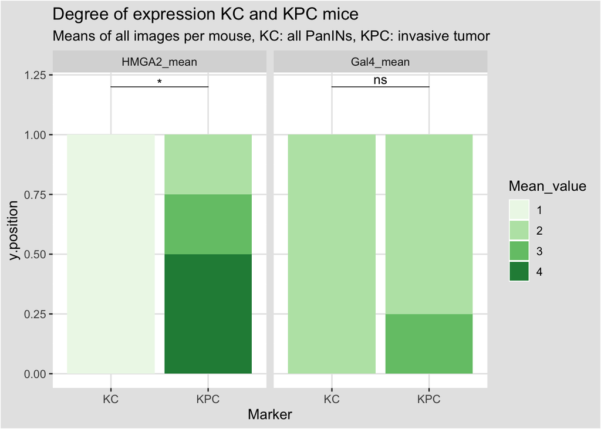

```r
#here change the Mean_value to factor to enable making a stacked barplot
mKC_KPCmeans_GH$Mean_value <- as.factor(mKC_KPCmeans_GH$Mean_value)

bars_meanspermouse_sign <- mKC_KPCmeans_GH %>% ggplot() +
  geom_bar(aes(x = Mouse_type, fill = Mean_value), position = "fill") +
labs(title = "Degree of expression KC and KPC mice", subtitle = "Means of all images per mouse, KC: all PanINs, KPC: invasive tumor", x = "Marker") +
 facet_grid(. ~ Marker) +
  theme_igray() +
  scale_fill_brewer(palette = "Greens")  +
  stat_pvalue_manual(res.wil_KCKPC_GH_bar, label = 'p.adj.signif')
bars_meanspermouse_sign
```

# Focusing on the PanINs of KC mice: separating high and low grade

```r
KC_panincalc <- lapply(KC_s, function (a) {
  a$mean_GATA6_Low <- round((mean(a$GATA6_L, na.rm = TRUE)))
  a$mean_GATA6_High <- round((mean(a$GATA6_H, na.rm = TRUE)))
  a$mean_HMGA2_Low <- round((mean(a$HMGA2_L, na.rm = TRUE)))
  a$mean_HMGA2_High <- round((mean(a$HMGA2_H, na.rm = TRUE)))
  a$mean_Gal4_Low <- round((mean(a$Gal4_L, na.rm = TRUE)))
  a$mean_Gal4_High <- round((mean(a$Gal4_H, na.rm = TRUE)))
  a
})
#KC_panincalc

KC_meanpanin_b <- bind_rows(KC_panincalc)

KC_meanpanin_a <- KC_meanpanin_b[, -c(2, 4:9)]
KC_meanpanin <- unique(KC_meanpanin_a)
KC_meanpanin # this contains the mean for each KC mouse separated for High - and low grade PanIN.
```

```
##    Mouse Mouse_type mean_GATA6_Low mean_GATA6_High mean_HMGA2_Low
## 1     45         KC              4               2              0
## 8     46         KC              3               3              1
## 16    49         KC              4               4              0
## 20    56         KC              4               4              0
##    mean_HMGA2_High mean_Gal4_Low mean_Gal4_High
## 1                1             3              0
## 8                1             3              0
## 16               2             3              1
## 20               2             4              0
```

Bars of relative frequences for PanINs, separated on high - and lowgrade PanIN.

```r
KC_meanpanin$Mouse <- as.factor(KC_meanpanin$Mouse)
KC_meanpanin$Mouse_type <- as.factor(KC_meanpanin$Mouse_type)
KC_meanpanin <- KC_meanpanin %>% mutate_at(c('mean_GATA6_Low', 'mean_GATA6_High', 'mean_HMGA2_Low', 'mean_HMGA2_High', 'mean_Gal4_Low', 'mean_Gal4_High'), as.factor)

mKC_meanpanin <- melt(KC_meanpanin, id.vars = c("Mouse", "Mouse_type"), value.name = "Mean_value", variable.name = "Marker")
```

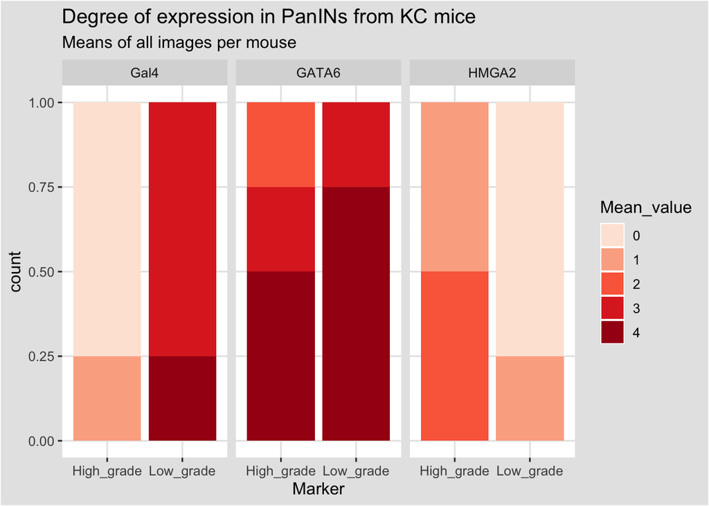

```r
#factor: PanIN differentiation
mKC_meanpanin$PanIN_grade <- factor(nrow(mKC_meanpanin))
mKC_meanpanin <- mKC_meanpanin %>% mutate(PanIN_grade = ifelse(grepl('Low', .$Marker), 'Low_grade', .$PanIN_grade))
mKC_meanpanin <- mKC_meanpanin %>% mutate(PanIN_grade = ifelse(grepl('High', .$Marker), 'High_grade', .$PanIN_grade))

#Now simplify the marker names
mKC_meanpanin$Marker <- as.character(mKC_meanpanin$Marker) # will otherwise return factor levels if 'no' in ifelse statement.
mKC_meanpanin <- mKC_meanpanin %>% mutate(Marker = ifelse(grepl('Gal4', .$Marker), 'Gal4', .$Marker))
mKC_meanpanin <- mKC_meanpanin %>% mutate(Marker = ifelse(grepl('GATA6', .$Marker), 'GATA6', .$Marker))
mKC_meanpanin <- mKC_meanpanin %>% mutate(Marker = ifelse(grepl('HMGA2', .$Marker), 'HMGA2', .$Marker))
mKC_meanpanin$Marker <- as.factor(mKC_meanpanin$Marker) #change back to factor

mKC_meanpanin$semiq <- factor(nrow(mKC_meanpanin))
mKC_meanpanin <- mKC_meanpanin %>% mutate(semiq = ifelse(grepl('0', .$Mean_value), '-', .$semiq))
mKC_meanpanin <- mKC_meanpanin %>% mutate(semiq = ifelse(grepl('1', .$Mean_value), '+', .$semiq))
mKC_meanpanin <- mKC_meanpanin %>% mutate(semiq = ifelse(grepl('2', .$Mean_value), '++', .$semiq))
mKC_meanpanin <- mKC_meanpanin %>% mutate(semiq = ifelse(grepl('3', .$Mean_value), '+++', .$semiq))
mKC_meanpanin <- mKC_meanpanin %>% mutate(semiq = ifelse(grepl('4', .$Mean_value), '++++', .$semiq))

bars_meansperPanIN <- mKC_meanpanin %>% ggplot(aes(x = PanIN_grade, fill = Mean_value)) +
  geom_bar(position = "fill") +
  labs(title = "Degree of expression in PanINs from KC mice", subtitle = "Means of all images per mouse", x = "Marker") +
  facet_grid(. ~ Marker) +
  theme_igray() +
  scale_fill_brewer(palette = "Reds")
bars_meansperPanIN
```

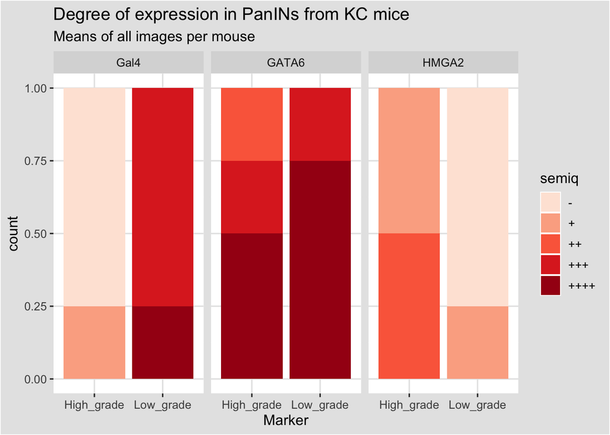

```r
bars_meansperPanIN_semiq <- mKC_meanpanin %>% ggplot(aes(x = PanIN_grade, fill = semiq)) +
  geom_bar(position = "fill") +
  labs(title = "Degree of expression in PanINs from KC mice", subtitle = "Means of all images per mouse", x = "Marker") +
  facet_grid(. ~ Marker) +
  theme_igray() +
  scale_fill_brewer(palette = "Reds")
bars_meansperPanIN_semiq
```

# Focusing on the KPC mice overall image compartments: Lobules and stroma

```r
KPC_mean_c <- KPC_mean_b[, -c(8:10)]
KPC_mean_c # this contains the score for each image from the KPC mice
```

```
##     Mouse     Image Mouse_type Gal4 GATA6 HMGA2 Dominant.compartment.of.image
## 1  436-3B Adipose C        KPC    2     2     3                       Adipose
## 2  436-3B Adipose B        KPC    2     2     2                       Adipose
## 3  436-3B Adipose A        KPC    3     3     3                       Adipose
## 4   436-5  Lobule A        KPC    3     4     3                       Lobular
## 5   436-5  Stroma A        KPC    2     2     4                        Stroma
## 6   436-7  Lobule A        KPC    2     3     4                       Lobular
## 7   605-4  Lobule A        KPC    3     4     2                       Lobular
## 8   605-4  Lobule B        KPC    3     4     3                       Lobular
## 9   605-4  Lobule C        KPC    4     3     2                       Lobular
## 10  605-4  Lobule E        KPC    3     4     2                       Lobular
```

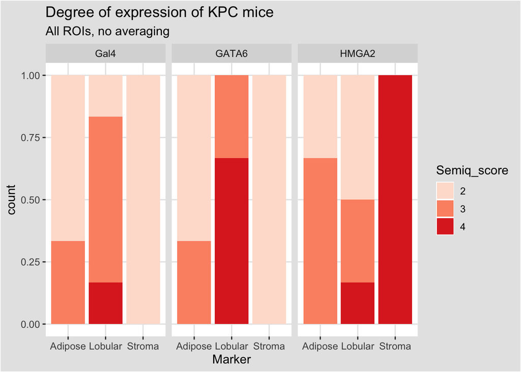

```r
colnames(KPC_mean_c) [7] <- "Compartment"

KPC_mean_c <- KPC_mean_c %>% mutate_at(c('GATA6', 'HMGA2', 'Gal4'), as.factor)

mKPC_mean_c <- melt(KPC_mean_c, id.vars = c("Mouse", "Image", "Mouse_type", "Compartment"), value.name = "Semiq_score", variable.name = "Marker")

mKPC_mean_c$semiq <- factor(nrow(mKPC_mean_c))
mKPC_mean_c <- mKPC_mean_c %>% mutate(semiq = ifelse(grepl('1', .$Semiq_score), '+', .$semiq))
mKPC_mean_c <- mKPC_mean_c %>% mutate(semiq = ifelse(grepl('2', .$Semiq_score), '++', .$semiq))
mKPC_mean_c <- mKPC_mean_c %>% mutate(semiq = ifelse(grepl('3', .$Semiq_score), '+++', .$semiq))
mKPC_mean_c <- mKPC_mean_c %>% mutate(semiq = ifelse(grepl('4', .$Semiq_score), '++++', .$semiq))

bars_KPCcompartment <- mKPC_mean_c %>% ggplot(aes(x = Compartment, fill = Semiq_score)) +
  geom_bar(position = "fill") +
  labs(title = "Degree of expression of KPC mice", subtitle = "All ROIs, no averaging", x = "Marker") +
  facet_grid(. ~ Marker) +
  theme_igray() +
  scale_fill_brewer(palette = "Reds")
bars_KPCcompartment
```

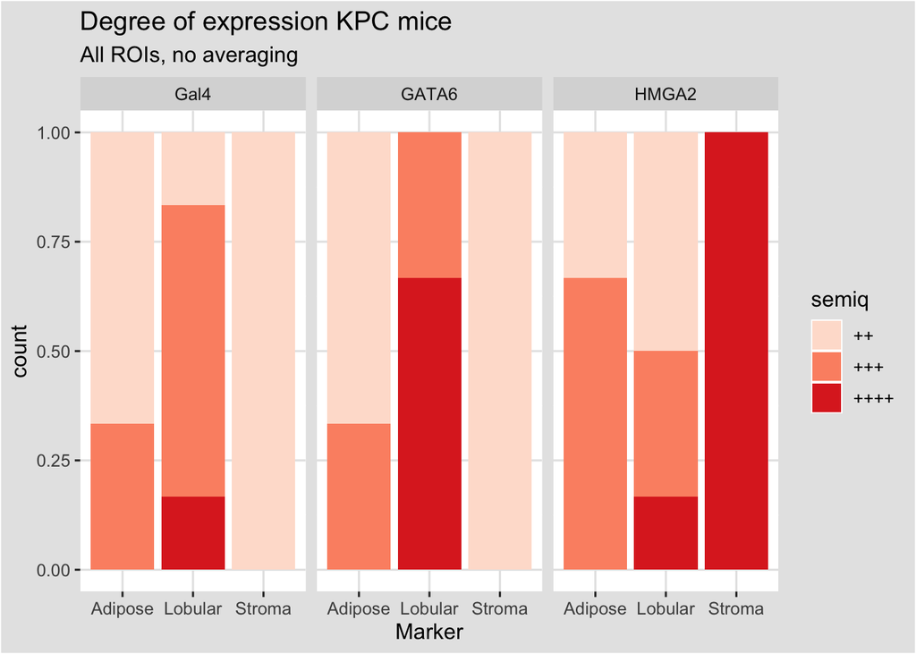

```r
bars_KPCcompartment_semiq <- mKPC_mean_c %>% ggplot(aes(x = Compartment, fill = semiq)) +
  geom_bar(position = "fill") +
  labs(title = "Degree of expression KPC mice", subtitle = "All ROIs, no averaging", x = "Marker") +
  facet_grid(. ~ Marker) +
  theme_igray() +
  scale_fill_brewer(palette = "Reds")
bars_KPCcompartment_semiq
```

Only 1 ROI was stromal. Pool this with the adipose:

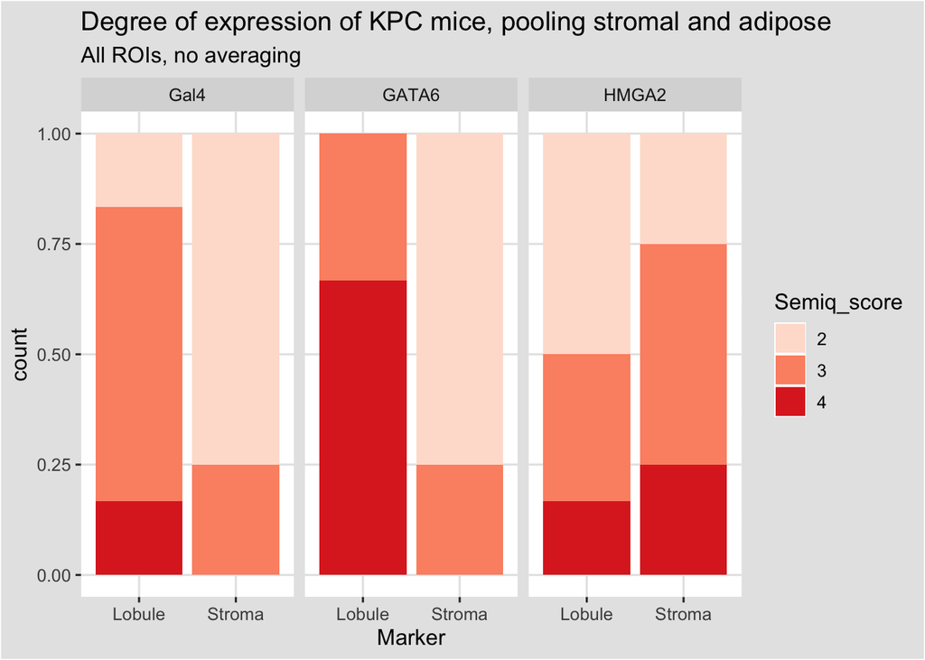

```r
mKPC_mean_cs <- mKPC_mean_c
mKPC_mean_cs$Compartments_v2 <- factor(nrow(mKPC_mean_cs))

mKPC_mean_cs <- mKPC_mean_cs %>% mutate(Compartments_v2 = ifelse(grepl('Adipose', .$Compartment), 'Stroma',  .$Compartments_v2))
mKPC_mean_cs <- mKPC_mean_cs %>% mutate(Compartments_v2 = ifelse(grepl('Stroma', .$Compartment), 'Stroma',  .$Compartments_v2))
mKPC_mean_cs <- mKPC_mean_cs %>% mutate(Compartments_v2 = ifelse(grepl('Lobular', .$Compartment), 'Lobule',  .$Compartments_v2))

bars_KPCcompartment2 <- mKPC_mean_cs %>% ggplot(aes(x = Compartments_v2, fill = Semiq_score)) +
  geom_bar(position = "fill") +
  labs(title = "Degree of expression of KPC mice, pooling stromal and adipose", subtitle = "All ROIs, no averaging", x = "Marker") +
  facet_grid(. ~ Marker) +
  theme_igray() +
  scale_fill_brewer(palette = "Reds")
bars_KPCcompartment2
```

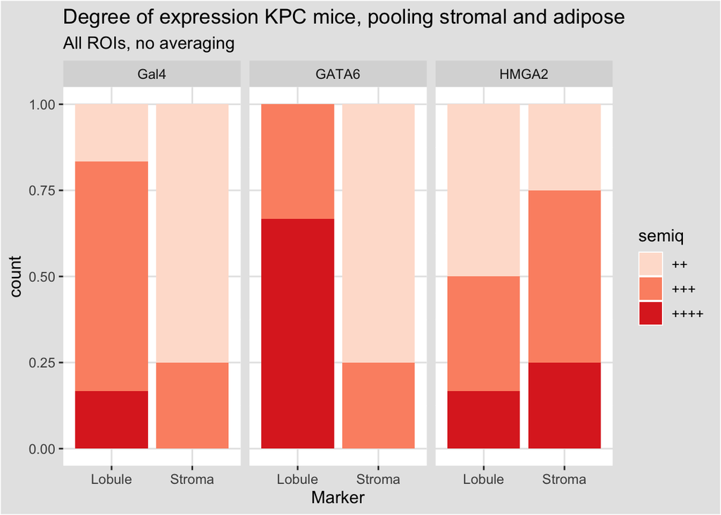

```r
bars_KPCcompartment2_semiq <- mKPC_mean_cs %>% ggplot(aes(x = Compartments_v2, fill = semiq)) +
  geom_bar(position = "fill") +
  labs(title = "Degree of expression KPC mice, pooling stromal and adipose", subtitle = "All ROIs, no averaging", x = "Marker") +
  facet_grid(. ~ Marker) +
  theme_igray() +
  scale_fill_brewer(palette = "Reds")
bars_KPCcompartment2_semiq
```

```r
mKC_KPCmeans$Mean_value <- as.numeric(mKC_KPCmeans$Mean_value)

# Wilcox test (non-paired)
res.wil_KCKPC <-  mKC_KPCmeans %>%
  group_by(Marker) %>%
  wilcox_test(Mean_value ~ Mouse_type)%>%
  adjust_pvalue(method = 'BH')%>%
  add_significance()
res.wil_KCKPC <- res.wil_KCKPC %>% add_xy_position(x = 'Mouse_type')
res.wil_KCKPC
```

```
## # A tibble: 3 × 14
##   Marker    .y.   group1 group2    n1    n2 statistic      p  p.adj p.adj.signif
##   <fct>     <chr> <chr>  <chr>  <int> <int>     <dbl>  <dbl>  <dbl> <chr>
## 1 GATA6_me… Mean… KC     KPC        4     4        11 0.429  0.453  ns
## 2 HMGA2_me… Mean… KC     KPC        4     4         0 0.0202 0.0606 ns
## 3 Gal4_mean Mean… KC     KPC        4     4         6 0.453  0.453  ns
## # ℹ 4 more variables: y.position <dbl>, groups <named list>, xmin <dbl>,
## #   xmax <dbl>
```

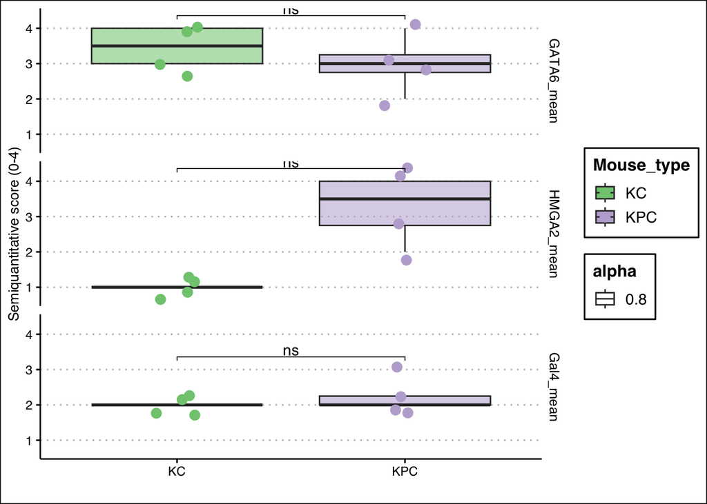

```r
boxKCKPC <- mKC_KPCmeans %>%
  ggplot(aes(x = Mouse_type, y = Mean_value))+
  geom_boxplot(outlier.shape = NA, aes(fill = Mouse_type, alpha = 0.8))+
  geom_jitter(aes(color = Mouse_type), alpha = 1, position=position_jitter(0.1), size = 3)+
  scale_color_brewer(palette = 'Accent')+
  scale_fill_brewer(palette = 'Accent')+
  labs(x = '', y = 'Semiquantitative score (0-4)')+
  theme_clean()+
  facet_grid(Marker ~ .) +
  stat_pvalue_manual(res.wil_KCKPC, label = 'p.adj.signif')
boxKCKPC
```

```r
mKC_meanpanin$Mean_value <- as.numeric(mKC_meanpanin$Mean_value)

res.wil_panin <-  mKC_meanpanin %>%
  group_by(Marker) %>%
  wilcox_test(Mean_value ~ PanIN_grade)%>%
  adjust_pvalue(method = 'BH')%>%
  add_significance()
res.wil_panin <- res.wil_panin %>% add_xy_position(x = 'PanIN_grade')
res.wil_panin
```

```
## # A tibble: 3 × 14
##   Marker .y.      group1 group2    n1    n2 statistic      p  p.adj p.adj.signif
##   <fct>  <chr>    <chr>  <chr>  <int> <int>     <dbl>  <dbl>  <dbl> <chr>
## 1 Gal4   Mean_va… High_… Low_g…     4     4       0   0.0228 0.0684 ns
## 2 GATA6  Mean_va… High_… Low_g…     4     4       5.5 0.505  0.505  ns
## 3 HMGA2  Mean_va… High_… Low_g…     4     4      15   0.0471 0.0706 ns
## # ℹ 4 more variables: y.position <dbl>, groups <named list>, xmin <dbl>,
## #   xmax <dbl>
```

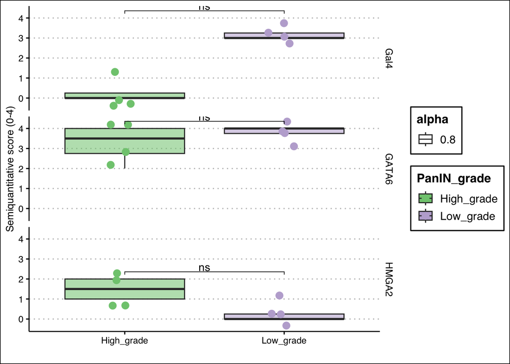

```r
box_panin <- mKC_meanpanin %>%
  ggplot(aes(x = PanIN_grade, y = Mean_value))+
  geom_boxplot(outlier.shape = NA, aes(fill = PanIN_grade, alpha = 0.8))+
  geom_jitter(aes(color = PanIN_grade), alpha = 1, position=position_jitter(0.1), size = 3)+
  scale_color_brewer(palette = 'Accent')+
  scale_fill_brewer(palette = 'Accent')+
          labs(x = '', y = 'Semiquantitative score (0-4)')+
  theme_clean()+
  facet_grid(Marker ~ .) +
    stat_pvalue_manual(res.wil_panin, label = 'p.adj.signif')
box_panin
```

```r
mKC_KPCmeans_GH <- mKC_KPCmeans[mKC_KPCmeans$Marker != "GATA6_mean", ]
mKC_KPCmeans_GH$Marker <- factor(mKC_KPCmeans_GH$Marker, levels = c("HMGA2_mean", "Gal4_mean"))
levels(mKC_KPCmeans_GH$Marker)
```

```
## [1] "HMGA2_mean" "Gal4_mean"
```

```r
unique((mKC_KPCmeans_GH$Marker))
```

```
## [1] HMGA2_mean Gal4_mean
## Levels: HMGA2_mean Gal4_mean
```

```r
# Wilcox test (non-paired)
res.wil_KCKPC_GH <-  mKC_KPCmeans_GH %>%
  group_by(Marker) %>%
  wilcox_test(Mean_value ~ Mouse_type)%>%
  adjust_pvalue(method = 'BH')%>%
  add_significance()
res.wil_KCKPC_GH <- res.wil_KCKPC_GH %>% add_xy_position(x = 'Mouse_type')
res.wil_KCKPC_GH
```

```
## # A tibble: 2 × 14
##   Marker    .y.   group1 group2    n1    n2 statistic      p  p.adj p.adj.signif
##   <fct>     <chr> <chr>  <chr>  <int> <int>     <dbl>  <dbl>  <dbl> <chr>
## 1 HMGA2_me… Mean… KC     KPC        4     4         0 0.0202 0.0404 *
## 2 Gal4_mean Mean… KC     KPC        4     4         6 0.453  0.453  ns
## # ℹ 4 more variables: y.position <dbl>, groups <named list>, xmin <dbl>,
## #   xmax <dbl>
```

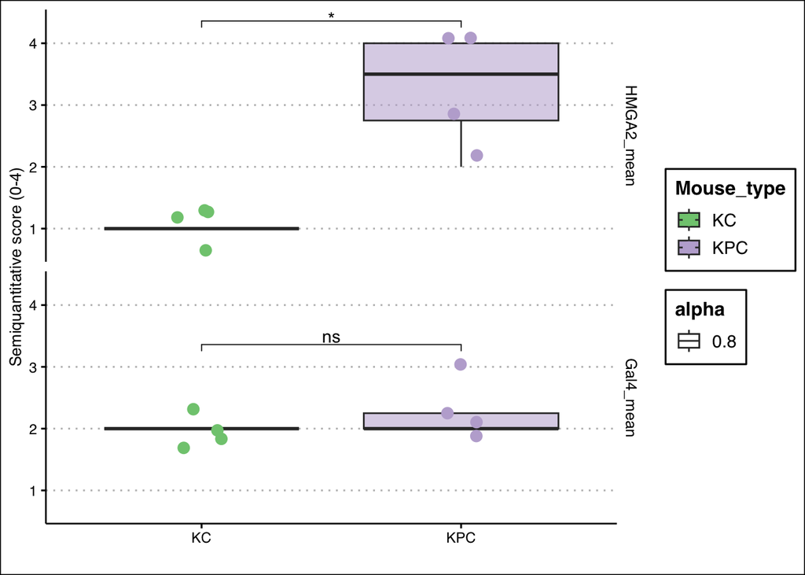

```r
boxKCKPC_GH <- mKC_KPCmeans_GH %>%
  ggplot(aes(x = Mouse_type, y = Mean_value))+
  geom_boxplot(outlier.shape = NA, aes(fill = Mouse_type, alpha = 0.8))+
  geom_jitter(aes(color = Mouse_type), alpha = 1, position = position_jitter(0.1), size = 3)+
  scale_color_brewer(palette = 'Accent')+
  scale_fill_brewer(palette = 'Accent')+
  labs(x = '', y = 'Semiquantitative score (0-4)')+
  theme_clean()+
  facet_grid(Marker ~ .) +
  stat_pvalue_manual(res.wil_KCKPC_GH, label = 'p.adj.signif')
boxKCKPC_GH
```

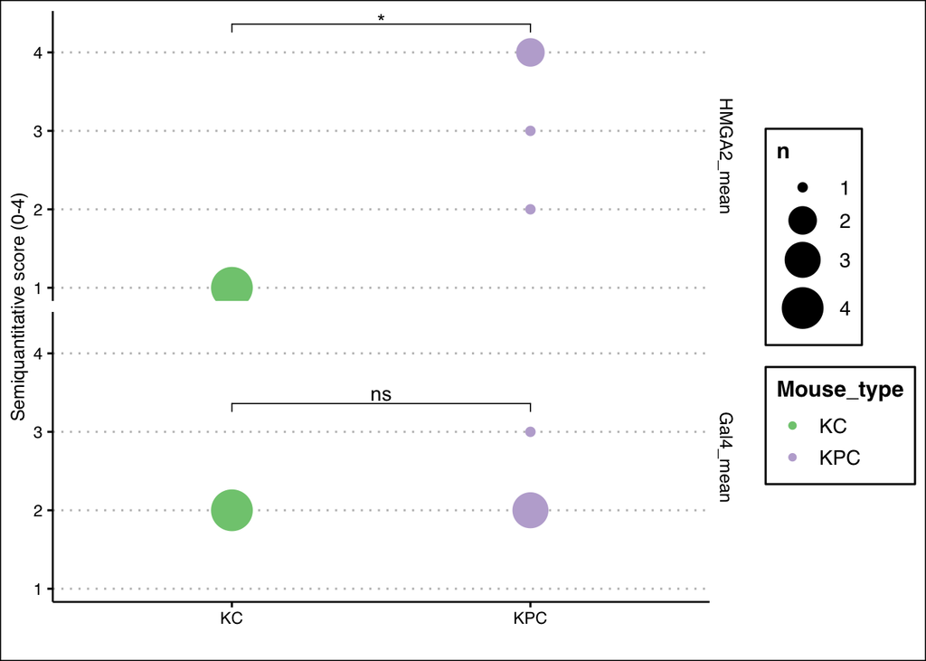

```r
pointKCKPC_GH <- mKC_KPCmeans_GH %>%
  ggplot(aes(x = Mouse_type, y = Mean_value))+
  geom_count(aes(fill = Mouse_type, color = Mouse_type))+
  scale_color_brewer(palette = 'Accent')+
  scale_fill_brewer(palette = 'Accent')+
  labs(x = '', y = 'Semiquantitative score (0-4)')+
  theme_clean()+
  facet_grid(Marker ~ .) +
  stat_pvalue_manual(res.wil_KCKPC_GH, label = 'p.adj.signif') +
  scale_size(range = c(2, 10))
pointKCKPC_GH
```

```r
mKC_meanpanin_GH <- mKC_meanpanin[mKC_meanpanin$Marker != "GATA6", ]
mKC_meanpanin_GH$Marker <- factor(mKC_meanpanin_GH$Marker, levels = c("HMGA2", "Gal4"))
levels(mKC_meanpanin_GH$Marker)
```

```
## [1] "HMGA2" "Gal4"
```

```r
unique(mKC_meanpanin_GH$Marker)
```

```
## [1] HMGA2 Gal4
## Levels: HMGA2 Gal4
```

```r
#wilcox test, unpaired
res.wil_panin_GH <-  mKC_meanpanin_GH %>%
  group_by(Marker) %>%
  wilcox_test(Mean_value ~ PanIN_grade)%>%
  adjust_pvalue(method = 'BH')%>%
  add_significance()
res.wil_panin_GH <- res.wil_panin_GH %>% add_xy_position(x = 'PanIN_grade')
res.wil_panin_GH
```

```
## # A tibble: 2 × 14
##   Marker .y.      group1 group2    n1    n2 statistic      p  p.adj p.adj.signif
##   <fct>  <chr>    <chr>  <chr>  <int> <int>     <dbl>  <dbl>  <dbl> <chr>
## 1 HMGA2  Mean_va… High_… Low_g…     4     4        15 0.0471 0.0471 *
## 2 Gal4   Mean_va… High_… Low_g…     4     4         0 0.0228 0.0456 *
## # ℹ 4 more variables: y.position <dbl>, groups <named list>, xmin <dbl>,
## #   xmax <dbl>
```

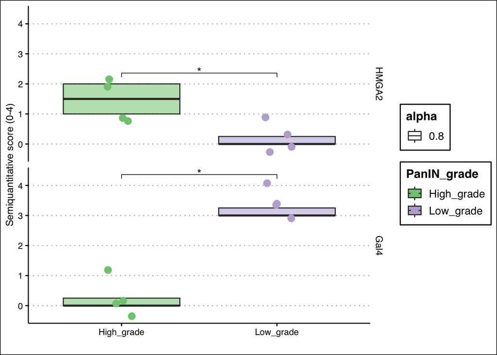

```r
box_panin_GH <- mKC_meanpanin_GH %>%
  ggplot(aes(x = PanIN_grade, y = Mean_value))+
  geom_boxplot(outlier.shape = NA, aes(fill = PanIN_grade, alpha = 0.8))+
  geom_jitter(aes(color = PanIN_grade), alpha = 1, position=position_jitter(0.1), size = 3)+
  scale_color_brewer(palette = 'Accent')+
  scale_fill_brewer(palette = 'Accent')+
  labs(x = '', y = 'Semiquantitative score (0-4)')+
  theme_clean()+
  facet_grid(Marker ~ .) +
  stat_pvalue_manual(res.wil_panin_GH, label = 'p.adj.signif')
box_panin_GH
```

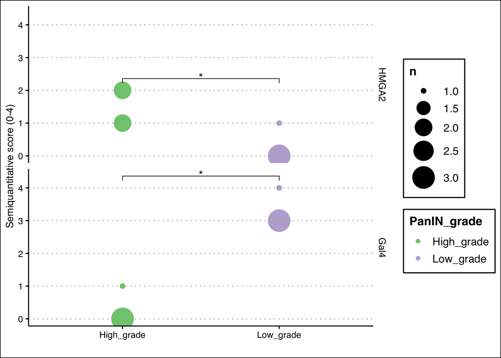

```r
point_panin_GH <- mKC_meanpanin_GH %>%
  ggplot(aes(x = PanIN_grade, y = Mean_value))+
  geom_count(aes(fill = PanIN_grade, color = PanIN_grade))+
  scale_color_brewer(palette = 'Accent')+
  scale_fill_brewer(palette = 'Accent')+
  labs(x = '', y = 'Semiquantitative score (0-4)')+
  theme_clean()+
  facet_grid(Marker ~ .) +
  stat_pvalue_manual(res.wil_panin_GH, label = 'p.adj.signif') +
  scale_size(range = c(2, 10))
point_panin_GH
```

KC PanINS - Gal4 and HMGA2 only, high grade vs low grade with significance indicators

```r
#Ensure numeric for statistical test
mKC_meanpanin_GH$Mean_value <- as.numeric(mKC_meanpanin_GH$Mean_value)

# Wilcox test (non-paired) for stacked barchart. Comparison: is there more of the respective markers in either of the two PanIN differentiation grades?
res.wil_KCPanINs_GH_bar <-  mKC_meanpanin_GH %>%
  group_by(Marker) %>%
  wilcox_test(Mean_value ~ PanIN_grade)%>%
  adjust_pvalue(method = 'BH')%>%
  add_significance()
res.wil_KCPanINs_GH_bar <- res.wil_KCPanINs_GH_bar %>% add_xy_position(x = 'PanIN_grade')
res.wil_KCPanINs_GH_bar [11] <- 1.2 #Making the plotting more compact
res.wil_KCPanINs_GH_bar
```

```
## # A tibble: 2 × 14
##   Marker .y.      group1 group2    n1    n2 statistic      p  p.adj p.adj.signif
##   <fct>  <chr>    <chr>  <chr>  <int> <int>     <dbl>  <dbl>  <dbl> <chr>
## 1 HMGA2  Mean_va… High_… Low_g…     4     4        15 0.0471 0.0471 *
## 2 Gal4   Mean_va… High_… Low_g…     4     4         0 0.0228 0.0456 *
## # ℹ 4 more variables: y.position <dbl>, groups <named list>, xmin <dbl>,
## #   xmax <dbl>
```

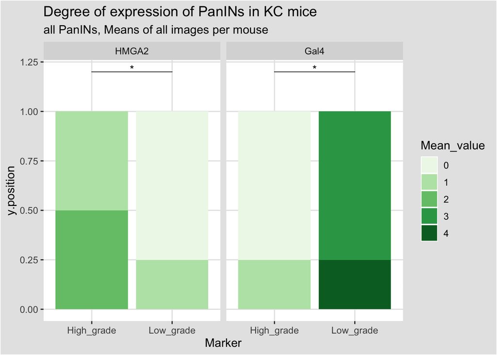

```r
#here change the Mean_value to factor to enable making a stacked barplot
mKC_meanpanin_GH$Mean_value <- as.factor(mKC_meanpanin_GH$Mean_value)

bars_meanspermouse_sign_KC <- mKC_meanpanin_GH %>% ggplot() +
  geom_bar(aes(x = PanIN_grade, fill = Mean_value), position = "fill") +
labs(title = "Degree of expression of PanINs in KC mice", subtitle = "all PanINs, Means of all images per mouse", x = "Marker") +
 facet_grid(. ~ Marker) +
  theme_igray() +
  scale_fill_brewer(palette = "Greens")  +
  stat_pvalue_manual(res.wil_KCPanINs_GH_bar, label = 'p.adj.signif')
bars_meanspermouse_sign_KC
```